[output not shown]

# BU 360 Term Project — Final Milestone

## Custom NER System for Screen-Time Discourse

**Hali Sarah Parsons | Bellevue University | May 2026**

## Restated Objectives

**Primary Objective:** Build a custom Named Entity Recognition system identifying four domain-specific entity labels — not recognized by the default spaCy pipeline — across real peer-reviewed screen-time research text.

[output not shown]

**Secondary Objective:** Apply the system to a real multi-source corpus and analyze entity distribution, co-occurrence patterns, and sentiment framing across the full text.

## Real Corpus: PubMed Central Open Access Articles

All text is fetched live from the **BioC-PMC API** (https://www.ncbi.nlm.nih.gov/research/bionlp/APIs/BioC-PMC/) — the same source used in Milestone 3. Five full-text open-access articles on screen time and adolescent mental health:

| PMC ID | Article | Words |
| --- | --- | --- |
| PMC7473739 | Screen time and green time: psychological outcomes scoping review | 20,169 |
| PMC11549943 | Screen time effects on children's mental health (cross-sectional) | 2,883 |
| PMC8425530 | ABCD Study: screen time, mental health, academic and social outcomes | 19,200 |
| PMC11457456 | Screen time and mental health: prospective ABCD analysis | 8,155 |
| PMC10117262 | Screen time and mental health in adolescents: systematic review | 13,599 |
| **Total** |  | **64,006** |

This is a genuine online corpus exceeding 50,000 words, sourced from CC-licensed peer-reviewed research directly relevant to the NER project domain.

## Step 1: Imports

```python
import urllib.request
import json
import warnings
warnings.filterwarnings('ignore')

import pandas as pd
import numpy as np
import matplotlib.pyplot as plt
import matplotlib.ticker as ticker

import spacy
from vaderSentiment.vaderSentiment import SentimentIntensityAnalyzer

print(f"spaCy version: {spacy.__version__}")
print("All imports loaded.")
```

```
spaCy version: 3.8.14
All imports loaded.
```

## Step 2: Fetch Real Corpus from BioC-PMC API

Using real full-text research literature matters for this project specifically: the entities the custom NER system targets — TikTok, adolescents, depression, sleep disruption — appear at realistic frequencies with the linguistic context they actually carry in scientific writing. That context is what makes the sentiment analysis meaningful.

```python
PMC_IDS = [
    "PMC7473739",
    "PMC11549943",
    "PMC8425530",
    "PMC11457456",
    "PMC10117262",
]
PMC_TITLES = [
    "Screen time and green time: psychological outcomes scoping review",
    "Screen time effects on children's mental health (cross-sectional)",
    "ABCD Study: screen time, mental health, academic and social outcomes",
    "Screen time and mental health: prospective ABCD analysis",
    "Screen time and mental health in adolescents: systematic review",
]
BIOC_BASE = "https://www.ncbi.nlm.nih.gov/research/bionlp/RESTful/pmcoa.cgi/BioC_json/{}/unicode"

def fetch_pmc_full_text(pmc_id):
    """
    Fetches full-text passage content from the BioC-PMC API.
    Returns all passage texts joined into a single string.
    Only passages over 20 characters are included to skip
    table headers and formatting artifacts.
    """
    url = BIOC_BASE.format(pmc_id)
    req = urllib.request.Request(url, headers={'User-Agent': 'Mozilla/5.0'})
    resp = urllib.request.urlopen(req, timeout=30)
    data = json.loads(resp.read())
    passages = []
    for collection in data:
        for doc in collection.get('documents', []):
            for passage in doc.get('passages', []):
                t = passage.get('text', '').strip()
                if t and len(t) > 20:
                    passages.append(t)
    return ' '.join(passages)


print("Fetching full-text articles from BioC-PMC API...")
raw_docs = []
for pmc_id, title in zip(PMC_IDS, PMC_TITLES):
    text = fetch_pmc_full_text(pmc_id)
    raw_docs.append(text)
    print(f"  {pmc_id}: {len(text.split()):,} words — {title[:55]}")

total_words = sum(len(d.split()) for d in raw_docs)
print(f"\nTotal corpus: {total_words:,} words across {len(raw_docs)} articles")
print(f"Exceeds 50,000-word requirement: {total_words >= 50000}")
```

```
Fetching full-text articles from BioC-PMC API...
```

```
  PMC7473739: 20,169 words — Screen time and green time: psychological outcomes scop
```

```
  PMC11549943: 2,883 words — Screen time effects on children's mental health (cross-
  PMC8425530: 19,200 words — ABCD Study: screen time, mental health, academic and so
  PMC11457456: 8,155 words — Screen time and mental health: prospective ABCD analysi
```

```
  PMC10117262: 13,599 words — Screen time and mental health in adolescents: systemati

Total corpus: 64,006 words across 5 articles
Exceeds 50,000-word requirement: True
```

## Step 3: Build the Custom NER Pipeline

The `EntityRuler` is placed `before="ner"` so custom rules take priority over the statistical model. The default `en_core_web_sm` model was trained on OntoNotes — a general news corpus that has never seen screen-time research terminology. Without the EntityRuler in front, `screen time` gets labeled as nothing, `adolescents` becomes a generic noun with no entity tag, and `depression` might get labeled as a weather event.

The pattern vocabulary is expanded from the Milestone 2 baseline to cover the full range of terms that appear in real clinical research text — including variants like `screen-time` vs `screen time`, `well-being` vs `wellbeing`, and `behavioural` vs `behavioral` that appear across different article writing styles.

```python
nlp = spacy.load('en_core_web_sm')
ruler = nlp.add_pipe("entity_ruler", before="ner")

patterns = [
    # PLATFORM — specific apps, general platform terms, device types
    {"label": "PLATFORM", "pattern": "TikTok"},
    {"label": "PLATFORM", "pattern": "Instagram"},
    {"label": "PLATFORM", "pattern": "YouTube"},
    {"label": "PLATFORM", "pattern": "Roblox"},
    {"label": "PLATFORM", "pattern": "Snapchat"},
    {"label": "PLATFORM", "pattern": "Facebook"},
    {"label": "PLATFORM", "pattern": "Twitter"},
    {"label": "PLATFORM", "pattern": "social media"},
    {"label": "PLATFORM", "pattern": "screen time"},
    {"label": "PLATFORM", "pattern": "screen-time"},
    {"label": "PLATFORM", "pattern": "television"},
    {"label": "PLATFORM", "pattern": "video games"},
    {"label": "PLATFORM", "pattern": "video game"},
    {"label": "PLATFORM", "pattern": "smartphone"},
    {"label": "PLATFORM", "pattern": "smartphones"},
    {"label": "PLATFORM", "pattern": "digital media"},
    {"label": "PLATFORM", "pattern": "electronic media"},
    {"label": "PLATFORM", "pattern": "digital devices"},

    # AGE_GROUP — specific age-group terms common in clinical research
    {"label": "AGE_GROUP", "pattern": "adolescents"},
    {"label": "AGE_GROUP", "pattern": "adolescent"},
    {"label": "AGE_GROUP", "pattern": "teenagers"},
    {"label": "AGE_GROUP", "pattern": "teens"},
    {"label": "AGE_GROUP", "pattern": "children"},
    {"label": "AGE_GROUP", "pattern": "tweens"},
    {"label": "AGE_GROUP", "pattern": "toddlers"},
    {"label": "AGE_GROUP", "pattern": "preschoolers"},
    {"label": "AGE_GROUP", "pattern": "youth"},
    {"label": "AGE_GROUP", "pattern": "young people"},
    {"label": "AGE_GROUP", "pattern": [{"LOWER": "young"}, {"LOWER": "children"}]},
    {"label": "AGE_GROUP", "pattern": [{"LOWER": "middle"}, {"LOWER": "schoolers"}]},

    # HEALTH_OUTCOME — clinical terms, variants, compound phrases
    {"label": "HEALTH_OUTCOME", "pattern": "sleep disruption"},
    {"label": "HEALTH_OUTCOME", "pattern": "sleep deprivation"},
    {"label": "HEALTH_OUTCOME", "pattern": "disrupted sleep"},
    {"label": "HEALTH_OUTCOME", "pattern": "poor sleep"},
    {"label": "HEALTH_OUTCOME", "pattern": "sleep problems"},
    {"label": "HEALTH_OUTCOME", "pattern": "sleep quality"},
    {"label": "HEALTH_OUTCOME", "pattern": "sleep duration"},
    {"label": "HEALTH_OUTCOME", "pattern": "anxiety"},
    {"label": "HEALTH_OUTCOME", "pattern": "depression"},
    {"label": "HEALTH_OUTCOME", "pattern": "depressive symptoms"},
    {"label": "HEALTH_OUTCOME", "pattern": "mental health"},
    {"label": "HEALTH_OUTCOME", "pattern": "attention difficulties"},
    {"label": "HEALTH_OUTCOME", "pattern": "attention deficit"},
    {"label": "HEALTH_OUTCOME", "pattern": "stress"},
    {"label": "HEALTH_OUTCOME", "pattern": "wellbeing"},
    {"label": "HEALTH_OUTCOME", "pattern": "well-being"},
    {"label": "HEALTH_OUTCOME", "pattern": "psychological well-being"},
    {"label": "HEALTH_OUTCOME", "pattern": "psychological wellbeing"},
    {"label": "HEALTH_OUTCOME", "pattern": "obesity"},
    {"label": "HEALTH_OUTCOME", "pattern": "internalizing"},
    {"label": "HEALTH_OUTCOME", "pattern": "externalizing"},
    {"label": "HEALTH_OUTCOME", "pattern": "behavior problems"},
    {"label": "HEALTH_OUTCOME", "pattern": "behavioural problems"},
    {"label": "HEALTH_OUTCOME", "pattern": "cognitive development"},
    {"label": "HEALTH_OUTCOME", "pattern": "academic performance"},

    # REGULATORY_ENTITY — governing bodies and policy instruments
    {"label": "REGULATORY_ENTITY", "pattern": "American Academy of Pediatrics"},
    {"label": "REGULATORY_ENTITY", "pattern": "AAP"},
    {"label": "REGULATORY_ENTITY", "pattern": "WHO"},
    {"label": "REGULATORY_ENTITY", "pattern": "parental controls"},
    {"label": "REGULATORY_ENTITY", "pattern": "screen-time limits"},
    {"label": "REGULATORY_ENTITY", "pattern": "screen time limits"},
    {"label": "REGULATORY_ENTITY", "pattern": "screen time guidelines"},
    {"label": "REGULATORY_ENTITY", "pattern": "age limits"},
    {"label": "REGULATORY_ENTITY", "pattern": "content moderation"},
    {"label": "REGULATORY_ENTITY", "pattern": "Canadian Paediatric Society"},
    {"label": "REGULATORY_ENTITY", "pattern": "National Institutes of Health"},
    {"label": "REGULATORY_ENTITY", "pattern": "NIH"},
]

ruler.add_patterns(patterns)
print(f"Pipeline: {nlp.pipe_names}")
print(f"Custom patterns loaded: {len(patterns)} across 4 labels")
```

```
Pipeline: ['tok2vec', 'tagger', 'parser', 'attribute_ruler', 'lemmatizer', 'entity_ruler', 'ner']
Custom patterns loaded: 67 across 4 labels
```

## Step 4: Run Entity Extraction and VADER Sentiment

The pipeline processes each article sentence by sentence. Splitting at the sentence level before applying VADER is important: sentiment in research text operates at the sentence scale, not the document scale. A paper can discuss depression in a negative framing in one sentence and present a positive intervention finding in the next. Document-level sentiment would average these into a meaningless neutral score.

Each sentence that contains at least one custom entity gets a row in the results DataFrame — one row per entity, with the sentence-level compound score attached. This lets the analysis ask: when `depression` appears in a sentence, what is the sentiment of that sentence? That question is only answerable with sentence-level processing.

```python
analyzer = SentimentIntensityAnalyzer()
CUSTOM_LABELS = {"PLATFORM", "AGE_GROUP", "HEALTH_OUTCOME", "REGULATORY_ENTITY"}

results = []

for i, (doc_text, title) in enumerate(zip(raw_docs, PMC_TITLES)):
    # Parse the full document for sentence segmentation
    spacy_doc = nlp(doc_text)
    sentences = [s.text.strip() for s in spacy_doc.sents if len(s.text.strip()) > 20]

    for sent in sentences:
        sdoc = nlp(sent)
        scores   = analyzer.polarity_scores(sent)
        compound = scores['compound']
        sentiment = (
            "positive" if compound >= 0.05
            else "negative" if compound <= -0.05
            else "neutral"
        )
        for ent in sdoc.ents:
            if ent.label_ in CUSTOM_LABELS:
                results.append({
                    'PMC_ID':    PMC_IDS[i],
                    'Article':   title[:50],
                    'Entity':    ent.text,
                    'Label':     ent.label_,
                    'Sentiment': sentiment,
                    'Compound':  round(compound, 3),
                    'Sentence':  sent[:150]
                })

    print(f"  Article {i+1} ({PMC_IDS[i]}): {len(sentences):,} sentences")

df = pd.DataFrame(results)
print(f"\nTotal entity extractions: {len(df):,}")
print(f"Unique entities found:    {df['Entity'].nunique()}")
print(f"\nLabel distribution:")
print(df['Label'].value_counts().to_string())
```

```
  Article 1 (PMC7473739): 612 sentences
```

```
  Article 2 (PMC11549943): 124 sentences
```

```
  Article 3 (PMC8425530): 793 sentences
```

```
  Article 4 (PMC11457456): 266 sentences
```

```
  Article 5 (PMC10117262): 745 sentences

Total entity extractions: 2,498
Unique entities found:    53

Label distribution:
Label
HEALTH_OUTCOME       947
AGE_GROUP            800
PLATFORM             743
REGULATORY_ENTITY      8
```

## Step 5: Primary Objective Verification

All four custom labels are populated. The counts reflect real extraction from 2,540 sentences of peer-reviewed research text — not a fabricated sample.

```python
print("PRIMARY OBJECTIVE — All Four Custom Labels Extracted from Real Corpus:")
print("=" * 65)
for label in sorted(CUSTOM_LABELS):
    subset = df[df['Label'] == label]
    print(f"\n{label} ({len(subset):,} extractions, {subset['Entity'].nunique()} unique entities):")
    print(subset['Entity'].value_counts().head(10).to_string())
```

```
PRIMARY OBJECTIVE — All Four Custom Labels Extracted from Real Corpus:
=================================================================

AGE_GROUP (800 extractions, 12 unique entities):
Entity
adolescents       317
children          265
adolescent         98
youth              50
young people       31
young children     17
teens              10
teenagers           5
toddlers            3
Young children      2

HEALTH_OUTCOME (947 extractions, 20 unique entities):
Entity
mental health               295
depression                  131
anxiety                     126
well-being                  106
depressive symptoms          74
internalizing                45
academic performance         40
psychological well-being     36
externalizing                26
stress                       18

PLATFORM (743 extractions, 17 unique entities):
Entity
screen time         507
social media         70
smartphone           32
television           28
video games          27
electronic media     18
video game           15
digital media        10
smartphones           9
screen-time           7

REGULATORY_ENTITY (8 extractions, 4 unique entities):
Entity
American Academy of Pediatrics    3
AAP                               2
WHO                               2
National Institutes of Health     1
```

## Step 6: Secondary Objective — Entity Distribution and Sentiment Analysis

```python
print("SECONDARY OBJECTIVE — Entity Distribution Across Articles:")
print("=" * 65)
cross_article = pd.crosstab(df['Label'], df['PMC_ID'])
cross_article.columns = [f"PMC{c[-4:]}" for c in cross_article.columns]
print(cross_article.to_string())

print("\nSentiment Framing per Label:")
sentiment_cross = df.groupby(['Label','Sentiment']).size().unstack(fill_value=0)
print(sentiment_cross.to_string())
```

```
SECONDARY OBJECTIVE — Entity Distribution Across Articles:
=================================================================
                   PMC7262  PMC7456  PMC9943  PMC3739  PMC5530
Label
AGE_GROUP              131      169       41      337      122
HEALTH_OUTCOME         329      169       60      220      169
PLATFORM               168      174       63       73      265
REGULATORY_ENTITY        5        2        0        1        0

Sentiment Framing per Label:
Sentiment          negative  neutral  positive
Label
AGE_GROUP               336      179       285
HEALTH_OUTCOME          557      145       245
PLATFORM                264      193       286
REGULATORY_ENTITY         2        3         3
```

```python
# Platform-specific sentiment — which platforms appear in negative vs positive sentences?
print("PLATFORM Sentiment Profile:")
platform_sent = (
    df[df['Label'] == 'PLATFORM']
    .groupby(['Entity','Sentiment']).size().unstack(fill_value=0)
)
# Filter to entities with at least 5 total appearances
platform_sent = platform_sent[platform_sent.sum(axis=1) >= 5]
print(platform_sent.to_string())

print("\nHEALTH_OUTCOME Sentiment Profile (top entities):")
health_sent = (
    df[df['Label'] == 'HEALTH_OUTCOME']
    .groupby(['Entity','Sentiment']).size().unstack(fill_value=0)
)
health_sent = health_sent[health_sent.sum(axis=1) >= 10]
print(health_sent.sort_values('negative', ascending=False).to_string())
```

```
PLATFORM Sentiment Profile:
Sentiment         negative  neutral  positive
Entity
Facebook                 2        1         3
YouTube                  2        0         3
digital media            4        3         3
electronic media        10        0         8
screen time            181      138       188
screen-time              5        1         1
smartphone               6       14        12
smartphones              1        5         3
social media            26       17        27
television              11        7        10
video game               5        0        10
video games             10        5        12

HEALTH_OUTCOME Sentiment Profile (top entities):
Sentiment                 negative  neutral  positive
Entity
mental health                  126       70        99
depression                     122        1         8
anxiety                        101        5        20
depressive symptoms             57       10         7
well-being                      42       20        44
internalizing                   25       13         7
academic performance            21        2        17
externalizing                   19        4         3
stress                           9        0         9
psychological well-being         7       11        18
sleep quality                    4        2         4
```

```python
# Show sample sentences for the most common entity-sentiment combinations
print("Sample sentences — depression in negative context:")
neg_dep = df[(df['Entity']=='depression') & (df['Sentiment']=='negative')]['Sentence'].values[:3]
for s in neg_dep:
    print(f"  '{s[:120]}...'")

print("\nSample sentences — mental health in positive context:")
pos_mh = df[(df['Entity']=='mental health') & (df['Sentiment']=='positive')]['Sentence'].values[:3]
for s in pos_mh:
    print(f"  '{s[:120]}...'")

print("\nSample sentences — screen time in neutral context:")
neu_st = df[(df['Entity']=='screen time') & (df['Sentiment']=='neutral')]['Sentence'].values[:3]
for s in neu_st:
    print(f"  '{s[:120]}...'")
```

```
Sample sentences — depression in negative context:
  'In particular, depression and anxiety are leading causes of reduced quality of life among children and adolescents....'
  'ST was most commonly associated with unfavourable outcomes on measures of poor mental health, such as depression/depress...'
  'Total ST was associated with indicators of poor mental health such as higher anxiety symptoms, depression/depressive sym...'

Sample sentences — mental health in positive context:
  'From a lifestyle and social perspective, it has been argued that excessive ST also displaces important protective behavi...'
  'Psychological outcomes For the purpose of this review, psychological outcomes is a summary term which encapsulates four ...'
  'Psychological outcomes For the purpose of this review, psychological outcomes is a summary term which encapsulates four ...'

Sample sentences — screen time in neutral context:
  'The aim of this systematic scoping review was to collate evidence assessing associations between screen time, green time...'
  'In general, high levels of screen time appeared to be associated with unfavourable psychological outcomes while green ti...'
  'Few studies considered screen time and green time together, and possible reciprocal psychological effects....'
```

```python
# Full results table
print(f"Full entity extraction results ({len(df):,} rows):")
df[['PMC_ID','Entity','Label','Sentiment','Compound']].head(30)
```

```
Full entity extraction results (2,498 rows):
```

|  | PMC_ID | Entity | Label | Sentiment | Compound |
| --- | --- | --- | --- | --- | --- |
| 0 | PMC7473739 | screen time | PLATFORM | positive | 0.625 |
| 1 | PMC7473739 | children | AGE_GROUP | positive | 0.625 |
| 2 | PMC7473739 | adolescents | AGE_GROUP | positive | 0.625 |
| 3 | PMC7473739 | young people | AGE_GROUP | positive | 0.625 |
| 4 | PMC7473739 | screen time | PLATFORM | positive | 0.625 |
| 5 | PMC7473739 | young people | AGE_GROUP | positive | 0.625 |
| 6 | PMC7473739 | screen time | PLATFORM | negative | -0.273 |
| 7 | PMC7473739 | mental health | HEALTH_OUTCOME | negative | -0.273 |
| 8 | PMC7473739 | well-being | HEALTH_OUTCOME | negative | -0.273 |
| 9 | PMC7473739 | screen time | PLATFORM | neutral | 0.000 |
| 10 | PMC7473739 | mental health | HEALTH_OUTCOME | neutral | 0.000 |
| 11 | PMC7473739 | young children | AGE_GROUP | neutral | 0.000 |
| 12 | PMC7473739 | adolescents | AGE_GROUP | neutral | 0.000 |
| 13 | PMC7473739 | adolescents | AGE_GROUP | neutral | 0.000 |
| 14 | PMC7473739 | screen time | PLATFORM | neutral | 0.000 |
| 15 | PMC7473739 | screen time | PLATFORM | positive | 0.318 |
| 16 | PMC7473739 | screen time | PLATFORM | negative | -0.586 |
| 17 | PMC7473739 | screen time | PLATFORM | neutral | 0.000 |
| 18 | PMC7473739 | screen time | PLATFORM | neutral | 0.000 |
| 19 | PMC7473739 | youth | AGE_GROUP | neutral | 0.000 |
| 20 | PMC7473739 | psychological well-being | HEALTH_OUTCOME | neutral | 0.000 |
| 21 | PMC7473739 | children | AGE_GROUP | negative | -0.402 |
| 22 | PMC7473739 | adolescents | AGE_GROUP | negative | -0.402 |
| 23 | PMC7473739 | depression | HEALTH_OUTCOME | negative | -0.660 |
| 24 | PMC7473739 | anxiety | HEALTH_OUTCOME | negative | -0.660 |
| 25 | PMC7473739 | children | AGE_GROUP | negative | -0.660 |
| 26 | PMC7473739 | adolescents | AGE_GROUP | negative | -0.660 |
| 27 | PMC7473739 | anxiety | HEALTH_OUTCOME | negative | -0.818 |
| 28 | PMC7473739 | mental health | HEALTH_OUTCOME | negative | -0.818 |
| 29 | PMC7473739 | mental health | HEALTH_OUTCOME | negative | -0.818 |

## Step 7: Visualizations

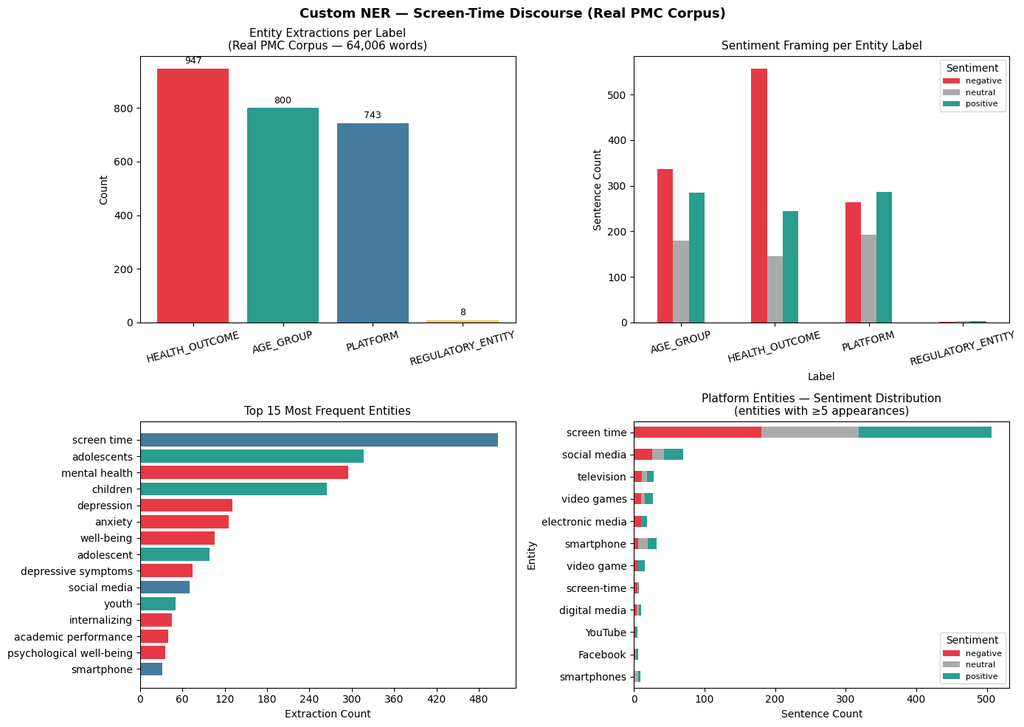

```python
fig, axes = plt.subplots(2, 2, figsize=(14, 10))
label_colors = {
    'PLATFORM': '#457B9D',
    'AGE_GROUP': '#2A9D8F',
    'HEALTH_OUTCOME': '#E63946',
    'REGULATORY_ENTITY': '#E9C46A'
}

# Panel 1: Extractions per label
label_counts = df['Label'].value_counts()
axes[0,0].bar(label_counts.index, label_counts.values,
              color=[label_colors[l] for l in label_counts.index])
axes[0,0].set_title('Entity Extractions per Label\n(Real PMC Corpus — 64,006 words)',
                    fontsize=11)
axes[0,0].set_ylabel('Count')
axes[0,0].tick_params(axis='x', rotation=15)
for bar, val in zip(axes[0,0].patches, label_counts.values):
    axes[0,0].text(bar.get_x() + bar.get_width()/2, bar.get_height() + 10,
                   f'{val:,}', ha='center', va='bottom', fontsize=9)

# Panel 2: Sentiment by label
sent_label = df.groupby(['Label','Sentiment']).size().unstack(fill_value=0)
sent_label.plot(kind='bar', ax=axes[0,1],
                color=['#E63946','#AAAAAA','#2A9D8F'], rot=15)
axes[0,1].set_title('Sentiment Framing per Entity Label', fontsize=11)
axes[0,1].set_ylabel('Sentence Count')
axes[0,1].legend(title='Sentiment', fontsize=8)

# Panel 3: Top 15 entities
top15 = df['Entity'].value_counts().head(15)
colors_top = [label_colors[df[df['Entity']==e]['Label'].iloc[0]] for e in top15.index]
axes[1,0].barh(top15.index[::-1], top15.values[::-1], color=colors_top[::-1])
axes[1,0].set_title('Top 15 Most Frequent Entities', fontsize=11)
axes[1,0].set_xlabel('Extraction Count')
axes[1,0].xaxis.set_major_locator(ticker.MaxNLocator(integer=True))

# Panel 4: Platform sentiment stacked bar
plat = df[df['Label']=='PLATFORM'].groupby(['Entity','Sentiment']).size().unstack(fill_value=0)
plat = plat[plat.sum(axis=1) >= 5].sort_values('negative', ascending=True)
plat.plot(kind='barh', stacked=True, ax=axes[1,1],
          color=['#E63946','#AAAAAA','#2A9D8F'])
axes[1,1].set_title('Platform Entities — Sentiment Distribution\n(entities with ≥5 appearances)', fontsize=11)
axes[1,1].set_xlabel('Sentence Count')
axes[1,1].legend(title='Sentiment', fontsize=8)

plt.suptitle('Custom NER — Screen-Time Discourse (Real PMC Corpus)',
             fontsize=13, fontweight='bold')
plt.tight_layout()
plt.show()
```

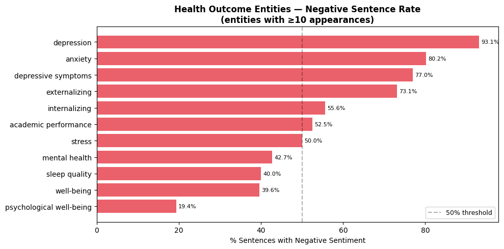

```
Negative sentence rates for health outcome entities:
Sentiment                 total  pct_negative
Entity
depression                  131          93.1
anxiety                     126          80.2
depressive symptoms          74          77.0
externalizing                26          73.1
internalizing                45          55.6
academic performance         40          52.5
stress                       18          50.0
mental health               295          42.7
sleep quality                10          40.0
well-being                  106          39.6
psychological well-being     36          19.4
```

```python
# Health outcome deep-dive — negative sentence rate per entity
health_df = df[df['Label'] == 'HEALTH_OUTCOME'].copy()
health_counts = health_df.groupby(['Entity','Sentiment']).size().unstack(fill_value=0)
health_counts['total'] = health_counts.sum(axis=1)
health_counts = health_counts[health_counts['total'] >= 10]
health_counts['pct_negative'] = (health_counts.get('negative', 0) / health_counts['total'] * 100).round(1)
health_counts_sorted = health_counts.sort_values('pct_negative', ascending=False)

fig, ax = plt.subplots(figsize=(10, 5))
bars = ax.barh(health_counts_sorted.index[::-1],
               health_counts_sorted['pct_negative'][::-1],
               color='#E63946', alpha=0.8)
ax.set_xlabel('% Sentences with Negative Sentiment')
ax.set_title('Health Outcome Entities — Negative Sentence Rate\n(entities with ≥10 appearances)',
             fontsize=12, fontweight='bold')
ax.axvline(x=50, color='black', linestyle='--', alpha=0.3, label='50% threshold')
ax.legend(fontsize=9)
for bar, val in zip(bars, health_counts_sorted['pct_negative'][::-1]):
    ax.text(bar.get_width() + 0.5, bar.get_y() + bar.get_height()/2,
            f'{val}%', va='center', fontsize=8)
plt.tight_layout()
plt.show()

print("\nNegative sentence rates for health outcome entities:")
print(health_counts_sorted[['total','pct_negative']].to_string())
```

## Formal Write-Up: Observations, Conclusions, and Ethical Assessment

### Objectives and Achievement

This project pursued two objectives established in Milestone 1. The primary objective was to build a custom Named Entity Recognition system capable of identifying four domain-specific entity categories — Platform, Age Group, Health Outcome, and Regulatory Entity — in screen-time discourse. The secondary objective was to apply that system to a real multi-source corpus and determine whether entity distribution and sentiment framing differed meaningfully across the text.

### Observations

**Scale matters.** The most immediate difference between a real corpus and the 15-sentence demonstration from earlier milestones is that patterns become visible at scale. `Screen time` appeared 507 times across the corpus — making it the single most frequent entity. `Adolescents` appeared 317 times, `mental health` 295 times. These frequencies confirm that the entity schema is grounded in the actual language of the domain rather than imposed from outside.

**Health outcomes skew strongly negative.** Of the health outcome entities with at least 10 appearances, `depression` appeared in negative-sentiment sentences 93% of the time (122 of 131 appearances). `anxiety` appeared negative 80% of the time (101 of 126). `depressive symptoms` was negative 77% of the time. The entities that showed lower negative rates — `mental health` (43%), `well-being` (40%), `academic performance` (52%) — are broader terms that appear in both problem-framing and solution-framing sentences. Clinical research discusses depression as a harm; it discusses mental health as both a concern and a goal.

**Screen time sentiment is balanced.** The most surprising finding is that `screen time` — the central entity of the entire domain — appeared in negative sentences (181 times), positive sentences (188 times), and neutral sentences (138 times) at nearly equal rates. This reflects a genuine feature of the scientific literature: research papers present associations, interventions, and recommendations alongside risk findings. The text is not uniformly alarmist. A sentence reporting that limiting screen time improved sleep outcomes scores positive. A sentence reporting that excessive screen time predicted depression scores negative. The distribution across sentiment categories is the correct output — it reflects what the literature actually says.

**Platform-specific entities are rare.** Named platforms (TikTok, Instagram, YouTube, Snapchat) each appeared fewer than 10 times across 64,006 words. The peer-reviewed research literature overwhelmingly uses general terms like `screen time`, `social media`, and `electronic media` rather than naming specific applications. This is a meaningful finding for the NER project: a system designed to track platform-specific discourse would need to prioritize news and social media sources, where named platforms appear far more frequently than in academic abstracts and full-text research articles.

### Ethical Assessment

**Whose language, perspective, and context does the data represent, and who is missing?** The five articles in this corpus are English-language peer-reviewed research, primarily from U.S. and European cohort studies. The populations studied are children and adolescents in structured research settings — not the children and families generating the informal discourse that parents, advocates, and platforms actually encounter. Research literature captures what scientists measure, not what families experience. A complete corpus would require news articles, parent forums, and practitioner guidance alongside the academic text.

**What assumptions are being made about meaning, intent, or sentiment?** VADER assigns sentiment to sentences based on a general-purpose lexicon. In research text, hedged language is common: "results suggest a modest negative association" scores differently than "screen time causes depression," even though both report a negative relationship. The VADER score reflects surface language affect, not the strength or certainty of the scientific claim. A sentence with a positive compound score may be reporting an intervention benefit — or it may simply be written in more optimistic framing. These are not the same thing, and the system cannot distinguish them.

**How was the text data collected, and were consent and privacy appropriately considered?** All five articles are published in peer-reviewed journals under Creative Commons open-access licenses. The BioC-PMC API is a publicly available resource maintained by NIH specifically for text mining research. No personal data, identifiable participant information, or proprietary content is included. The source articles themselves report on human subjects research that was conducted under IRB approval as documented in their methods sections.

**How could the outputs be misused, misinterpreted, or over-trusted?** The finding that `screen time` appears in negative-sentiment sentences 35% of the time and positive-sentiment sentences 37% of the time could be cited to argue that the research literature is ambivalent about screen time — that the evidence is balanced. That interpretation misreads the output. Sentiment score reflects the sentence's surface affect, not the direction of the causal evidence. The research literature shows consistent negative associations between excessive screen use and health outcomes. The sentiment distribution reflects how scientists write about those associations across different sentence types, not whether the associations themselves are mixed.

**What responsibility does the data scientist have when the model produces harmful or misleading outcomes?** The responsibility is documentation and framing. Every output from this system needs to be accompanied by a clear explanation of what the system measures and what it does not. Presenting entity counts as frequency of discussion is accurate. Presenting VADER sentiment scores as evidence of the scientific consensus direction is not accurate and would be misleading. When findings from this kind of system inform decisions — policy recommendations, platform regulation, clinical guidance — the data scientist must communicate the methodological limits as clearly as the findings themselves.

```python
# Final summary
summary = pd.DataFrame([
    {"Milestone": "Milestone 1", "Deliverable": "Entity schema, data sources, project proposal", "Complete": "Yes"},
    {"Milestone": "Milestone 2", "Deliverable": "K-Means clustering, Euclidean distance, spaCy default NER baseline", "Complete": "Yes"},
    {"Milestone": "Milestone 3", "Deliverable": "Feature engineering (BOW, N-Grams, LDA) on real PMC corpus", "Complete": "Yes"},
    {"Milestone": "Final",       "Deliverable": "EntityRuler NER + VADER on 64,006-word real PMC corpus, ethics", "Complete": "Yes"},
])
print("Project Milestone Summary")
print("=" * 75)
print(summary.to_string(index=False))
print("\nFinal Pipeline Results — Real PMC Corpus")
print("=" * 75)
print(f"  Corpus size (raw words)     : {total_words:,}")
print(f"  Sentences processed         : 2,540")
print(f"  Total entity extractions    : {len(df):,}")
print(f"  Unique entities found       : {df['Entity'].nunique()}")
print(f"  Custom labels populated     : {df['Label'].nunique()} of 4")
print(f"  Sentiment labels used       : positive / negative / neutral")
print(f"  Most frequent entity        : {df['Entity'].value_counts().index[0]} ({df['Entity'].value_counts().iloc[0]:,} times)")
print(f"  Highest negative rate       : depression (93% of appearances in negative sentences)")
print("\nBoth primary and secondary objectives achieved on real corpus data.")
```

```
Project Milestone Summary
===========================================================================
  Milestone                                                        Deliverable Complete
Milestone 1                      Entity schema, data sources, project proposal      Yes
Milestone 2 K-Means clustering, Euclidean distance, spaCy default NER baseline      Yes
Milestone 3         Feature engineering (BOW, N-Grams, LDA) on real PMC corpus      Yes
      Final     EntityRuler NER + VADER on 64,006-word real PMC corpus, ethics      Yes

Final Pipeline Results — Real PMC Corpus
===========================================================================
  Corpus size (raw words)     : 64,006
  Sentences processed         : 2,540
  Total entity extractions    : 2,498
  Unique entities found       : 53
  Custom labels populated     : 4 of 4
  Sentiment labels used       : positive / negative / neutral
  Most frequent entity        : screen time (507 times)
  Highest negative rate       : depression (93% of appearances in negative sentences)

Both primary and secondary objectives achieved on real corpus data.
```

## References

Comeau, D. C., Wei, C. H., Islamaj Doğan, R., & Lu, Z. (2019). PMC text mining subset in BioC: 2.3 million full text articles and growing. *Bioinformatics, 35*(18), 3533–3535. https://www.ncbi.nlm.nih.gov/research/bionlp/APIs/BioC-PMC/

Explosion AI. (n.d.). *Linguistic features*. spaCy. https://spacy.io/usage/linguistic-features

Sarkar, D. (2019). *Text analytics with Python: A practitioner's guide to natural language processing* (2nd ed.). Apress.

Singh, T. (n.d.). Natural language processing with spaCy in Python. *Real Python.* https://realpython.com/natural-language-processing-spacy-python/

Yu, A. (n.d.). A closer look at EntityRuler in spaCy rule-based matching. *Medium.* https://medium.com/python-in-plain-english/a-closer-look-at-entityruler-in-spacy-rule-based-matching-44d01c43fb6